# Algorithmic Trading

Firms have been forced to invest significantly in their trading and processing infrastructure by the increase in competition for lower transaction costs. However, without using automatic execution, a broker cannot conduct such giant order flow. For large brokerage firms, they benefit from algorithmic trading in competitions for lower-cost executions. That’s why algorithmic trading emerged.

Algorithmic trading originated on proprietary trading desks of investment banking firms. It is a solution for smaller spreads and market and market fragmentation. It is also capable of slicing large parent orders ensuring that each child order gets the best price. Traders can benefit from this process to complet large orders without disturbing the market. Current trading technology can decide the way they buy and sell. As the development of Data Science, advanced algorithms are capable of providing more choices.

# Moving Average

Moving average is a basic indicator to analyse price trend and momentumn. In R, packages to fix financial time series like “zoo”, “xts” and “quantmod” are useful tools for traders. We take the stock AAPL from 2015-09-26 to 2016-09-26 as data.

## Plot Simple Moving Average

### Plot Simple Moving Average by quantmod

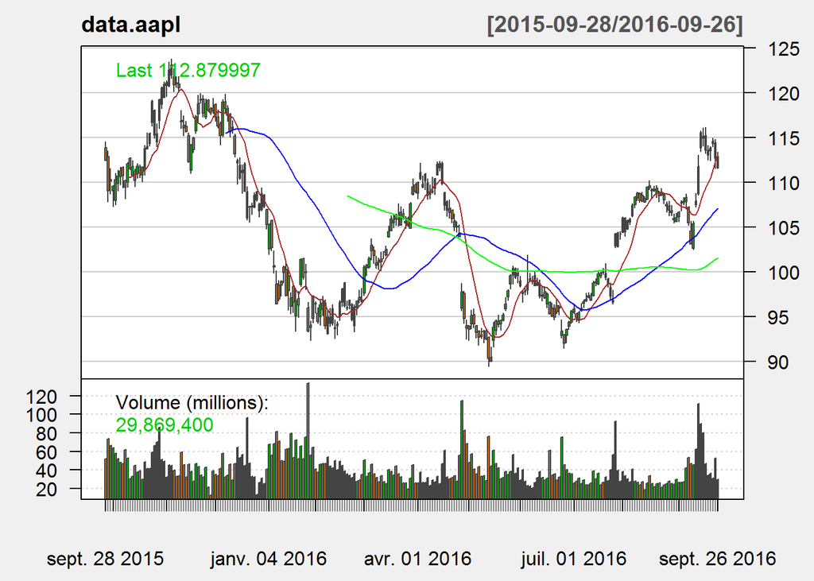

### Plot Simple Moving Average by Simple Plot

Two key functions of moving average are identifying trend and momentum. If a moving average is above the price, the stock is in an uptrend. In contrast, when a moving average is below the price, the stock is in downtrend. As for momentum, which refers to the rate of change on price movements, moving averages are used to represent short-term (less than 20 days), medium-term (20 to 100 days) and long-term (more than 100 days) price movements. Strong upward momentum is seen when shorter-term averages are located above longer-term averages and the two averages are diverging. Converse things in contrast.

[figure not shown]

## Exponential Moving Average Function and Plot

EMA is calculated by :
$$(close \,\, price-previous \,\, EMA)*multiplier + current \,\, EMA$$
$$multiplier = (2/(period \,\, of \,\, MA + 1))$$
Since recent prices are responsable more in EMA, EMA is more sensitive than SMA.

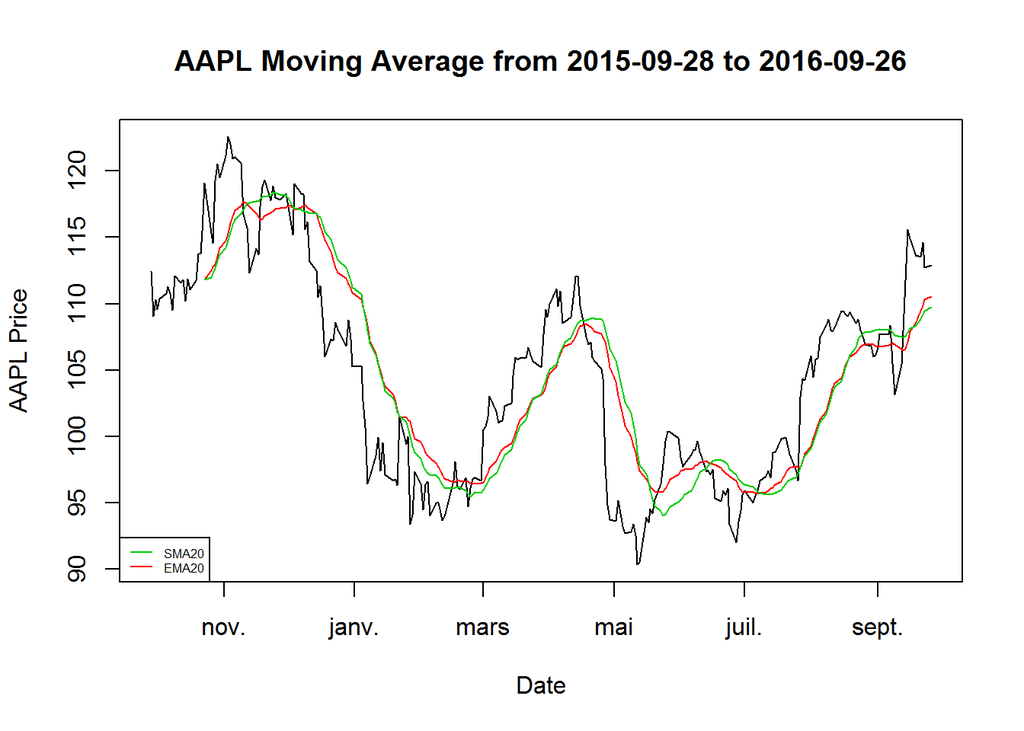

```r
ema <- function(sma, close.ema, timeperiod)
{
   multiplier <- (2/(timeperiod + 1))
   ema <- rep(0,length(sma))
   initial <- sma[timeperiod]

   ema[1:timeperiod-1] <- NA
   ema[timeperiod] <- initial

   for (i in timeperiod+1:length(sma)-1)
   {
     ema[i+1] <- (close.ema[i] - ema[i])*multiplier + ema[i]
   }
   return(ema[1:length(sma)])

}

ema20 <- zoo(ema(s20, data.quandl.close.ts, 20), order.by = td)
plot(data.quandl.close.ts, type = "l", main = "AAPL Moving Average from 2015-09-28 to 2016-09-26", xlab = "Date", ylab = "AAPL Price")
lines(ema20, col = 2)
lines(s20, col = 3)
legend("bottomleft", c("SMA20","EMA20"), col = c(3,2), lty = rep(1,2), pt.cex = 0.8, cex = rep(0.5,2))
```

### Ploting EMA20 by quantmod

```r
chartSeries(data.aapl,theme = "white")
```

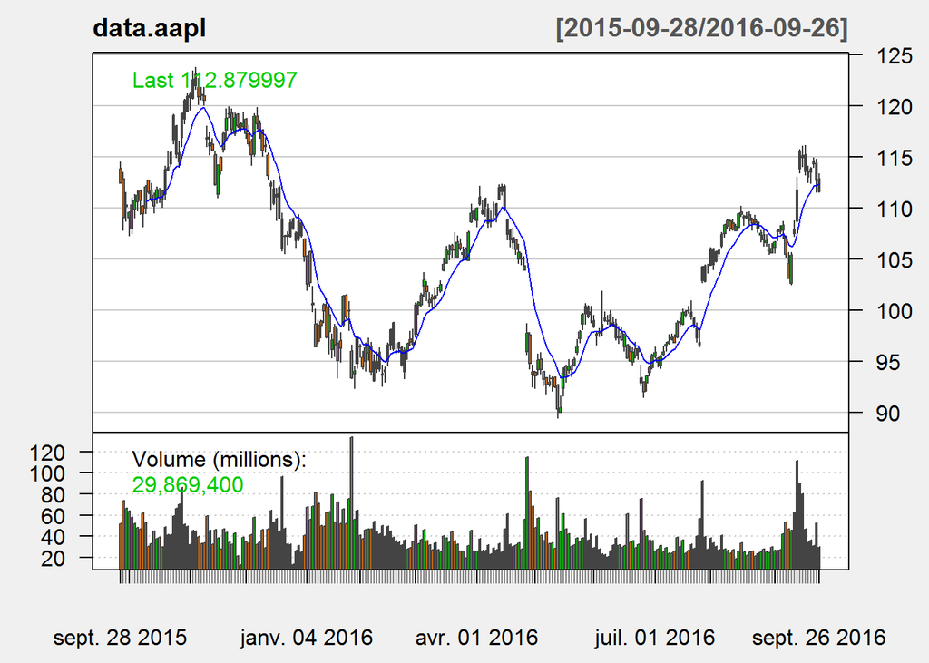

```r
addEMA()
```

## Function to Choose Long or Short Position

By using simple moving average, a function is created to indicate crossovers, that is, long or short position. They can be used to determine if prices are relatively high or low. Other indicators should be used with them.

```r
##=======================================
##Using simple moving average to decide long or short position.
##sma1 : ts; shorter-term moving average
##sma2 : ts; longer-term moving average
##price : ts; stock prices
##=======================================
long_short <- function(sma1, sma2, price)
{
  for (i in c(2:length(sma1)-1))
  {##eliminate effects of NA
    if((is.na(sma1[i]) == TRUE) || (is.na(sma2[i]) == TRUE))
    {next}
    if(sma1[i] != sma2[i])
    {
      if((sma1[i] < sma2[i]) && (sma1[i+1] > sma2[i+1]))
      {
        cat("Long position at", toString(index(sma1[i+1])), "\n", "The price is", coredata(price[i+1]), "\n")
      }
      if((sma1[i] > sma2[i]) && (sma1[i+1] < sma2[i+1]))
      {
        cat("Short position at", toString(index(sma1[i+1])), "\n", "The price is", coredata(price[i+1]), "\n")
      }
    }
    else
    {sprintf("Crossover at %s. The price is %f", index(sma1[i]), coredata(price[i]))}
  }
}

long_short(s10, s20, data.quandl.close.ts)
```

```
## Short position at 2015-11-17
##  The price is 113.69
## Long position at 2015-12-02
##  The price is 116.28
## Short position at 2015-12-11
##  The price is 113.18
## Long position at 2016-02-24
##  The price is 96.1
## Short position at 2016-04-22
##  The price is 105.68
## Long position at 2016-05-25
##  The price is 99.62
## Short position at 2016-06-17
##  The price is 95.33
## Long position at 2016-07-12
##  The price is 97.42
## Short position at 2016-08-31
##  The price is 106.1
## Long position at 2016-09-15
##  The price is 115.57
```

## Bollinger Bands for Simple Moving Average

Bollinger bands, which are placed two standard deviations away from a simple moving average, were invented to detect dynamic volitality. The formula is :
$$Upper\,\, Bollinger\,\, Bands = moving \,\,average + 2*standard\,\, deviation$$
$$Lower\,\, Bollinger\,\, Bands = moving\,\, average - 2*standard\,\, deviation$$
$$Middle\,\, Bollinger\,\, Bands = moving\,\, average$$

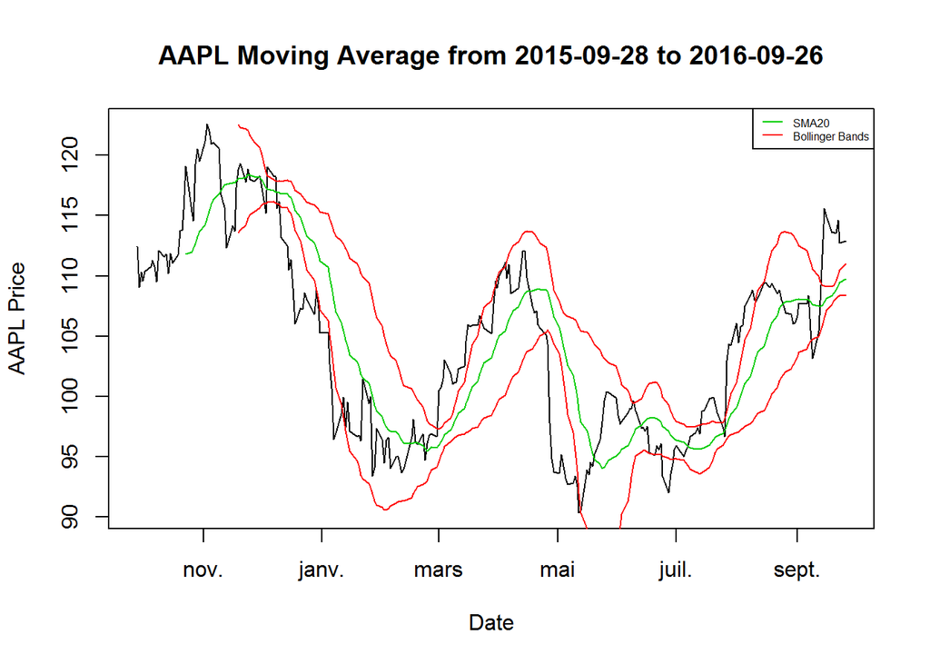

```r
bolband <- function(sma, day)
##============================
##sma : simple moving average
##day : period
##============================
{
   sd <- rollapply(sma, width = day, FUN = sd, fill = NA, align = "right")
   upperbol <- sma + 2*sd
   lowerbol <- sma - 2*sd
   return(list('upper' = upperbol, 'lower' = lowerbol))
}
bb <- bolband(s20, 20)
##plot bollinger average
plot(data.quandl.close.ts, type = "l", main = "AAPL Moving Average from 2015-09-28 to 2016-09-26", xlab = "Date", ylab = "AAPL Price")
lines(s20, col = 3)
lines(bb$upper, col = 2)
lines(bb$lower, col = 2)
legend("topright", c("SMA20","Bollinger Bands"), col = c(3,2), lty = rep(1,2), pt.cex = 0.8, cex = rep(0.5,2))
```

### Ploting Bollinger Bands by quantmod

```r
chartSeries(data.aapl,theme = "white")
```

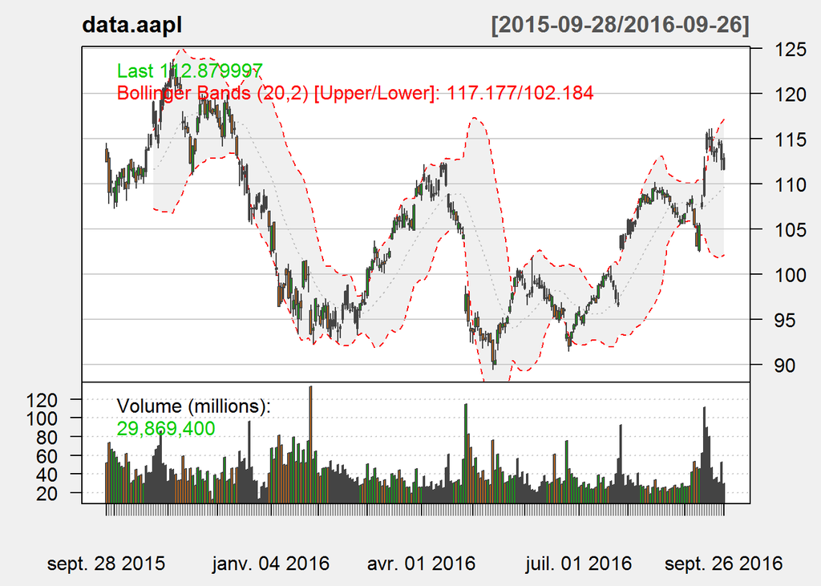

```r
addBBands()
```

## Function and Plot of MACD (Moving Average Convergence and Divergence)

MACD is calculated by substracting 26-day EMA from 12-day EMA. Signal is 9-day EMA of the MACD. The MACD oscillates above and below the zero line, which is also known as the centerline. These crossovers signal that the 12-day EMA has crossed the 26-day EMA. Positive MACD means that the momentum is upward. A bullish crossover occurs when the MACD turns up and crosses above the signal line.

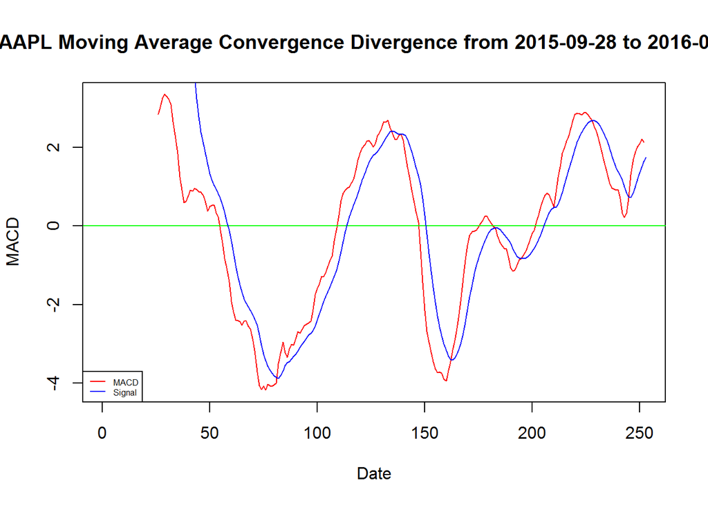

### Plot MACD by quantmod

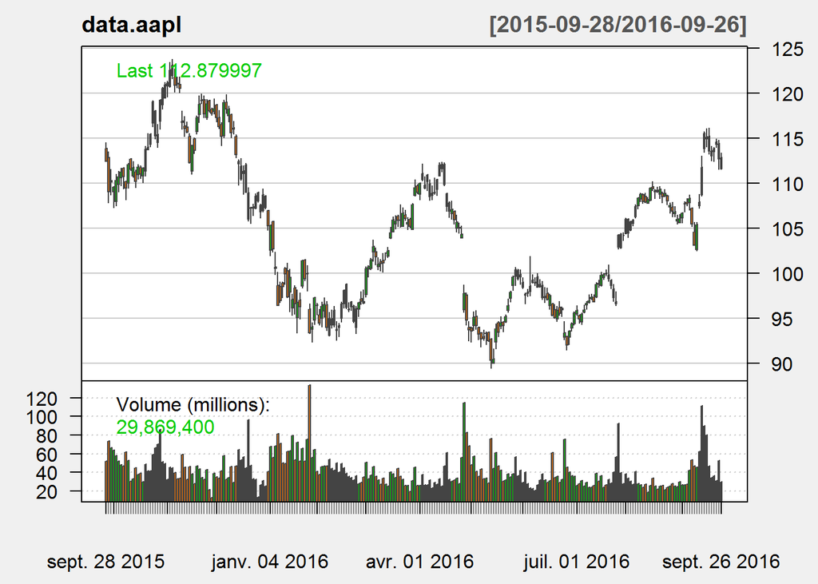

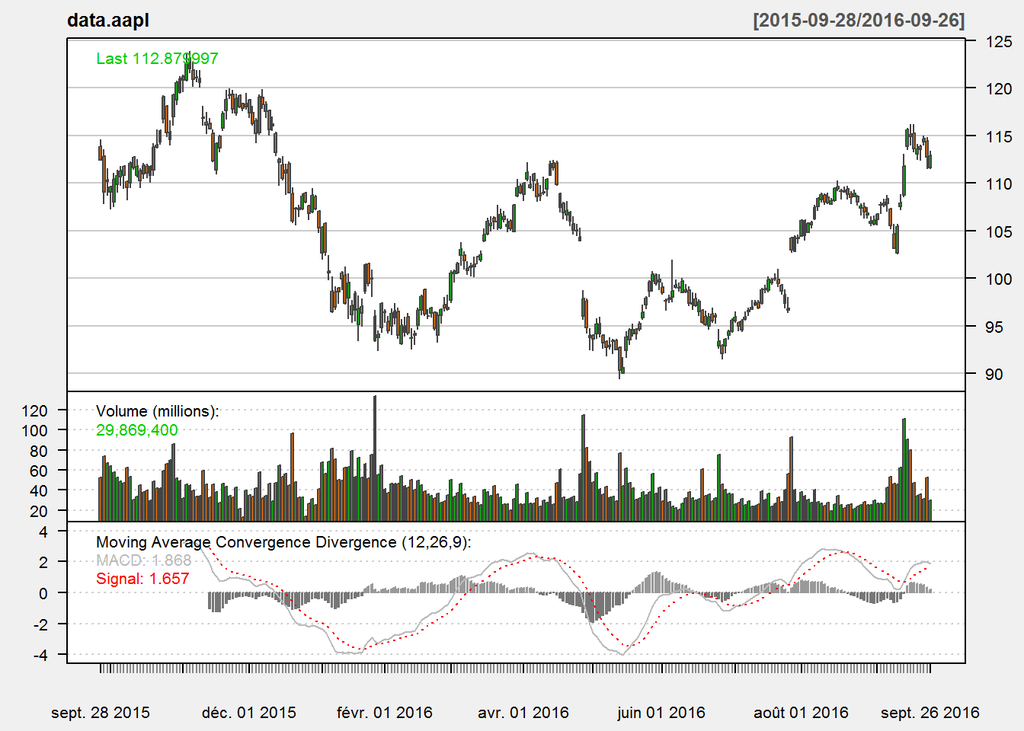

# VWAP

The volume weighted average price (VWAP) is a trading benchmark. It is the total traded value divided by the total traded volume. It is usually used by mutual funds, institutional investors and in pension plans in order not to disturb the market dynamics. That is, the aim of VWAP is to minimise the overall market impact and reduce the effect trading has on the asset’s price.  
We take intraday 1-minute data of AAPL at 2016-10-04 as data.

## Getting intraday 1-minute data of AAPL at 2016-10-04 from Google Finance

There is no cleaned intraday data which can be download from R directly, so munging data from Google Finance is necessary.

### The openning time

```
## [1] "2016-10-04 09:30:00 EST"
```

### Cleaned data

```
##                        CLOSE    HIGH      LOW     OPEN VOLUME TYPICALPRICE
## 2016-10-04 09:30:00 136.4643 136.500 136.4600 136.4864  23444     136.4748
## 2016-10-04 09:31:00 136.4500 136.490 136.4500 136.4700  21748     136.4633
## 2016-10-04 09:32:00 136.4400 136.460 136.4107 136.4500  31101     136.4369
## 2016-10-04 09:33:00 136.4300 136.445 136.4000 136.4300  34405     136.4250
## 2016-10-04 09:34:00 136.4500 136.460 136.4100 136.4370  48522     136.4400
## 2016-10-04 09:35:00 136.5000 136.510 136.4500 136.4500  28409     136.4867
##                          VP  TOTALVP TOTALV     VWAP
## 2016-10-04 09:30:00 3199514  3199514  23444 136.4748
## 2016-10-04 09:31:00 2967805  6167319  45192 136.4693
## 2016-10-04 09:32:00 4243324 10410643  76293 136.4561
## 2016-10-04 09:33:00 4693702 15104345 110698 136.4464
## 2016-10-04 09:34:00 6620342 21724687 159220 136.4445
## 2016-10-04 09:35:00 3877450 25602137 187629 136.4509
```

```
##                        CLOSE   HIGH      LOW     OPEN VOLUME TYPICALPRICE
## 2016-10-04 15:55:00 136.6400 136.72 136.6400 136.7000  68533     136.6667
## 2016-10-04 15:56:00 136.6407 136.69 136.6100 136.6400  62913     136.6469
## 2016-10-04 15:57:00 136.6200 136.66 136.5600 136.6400  87089     136.6133
## 2016-10-04 15:58:00 136.6150 136.63 136.5547 136.6150  43103     136.5999
## 2016-10-04 15:59:00 136.7400 136.79 136.6300 136.6300  87687     136.7200
## 2016-10-04 16:00:00 136.6600 136.75 136.6202 136.7456  51605     136.6767
##                           VP    TOTALVP   TOTALV     VWAP
## 2016-10-04 15:55:00  9366177 2357954595 17229323 136.8571
## 2016-10-04 15:56:00  8596866 2366551462 17292236 136.8563
## 2016-10-04 15:57:00 11897519 2378448980 17379325 136.8551
## 2016-10-04 15:58:00  5887865 2384336846 17422428 136.8545
## 2016-10-04 15:59:00 11988567 2396325413 17510115 136.8538
## 2016-10-04 16:00:00  7053203 2403378615 17561720 136.8533
```

## Plot of VWAP

When VWAP is over the stock price, it is a long position. The contract is true when VWAP is below.

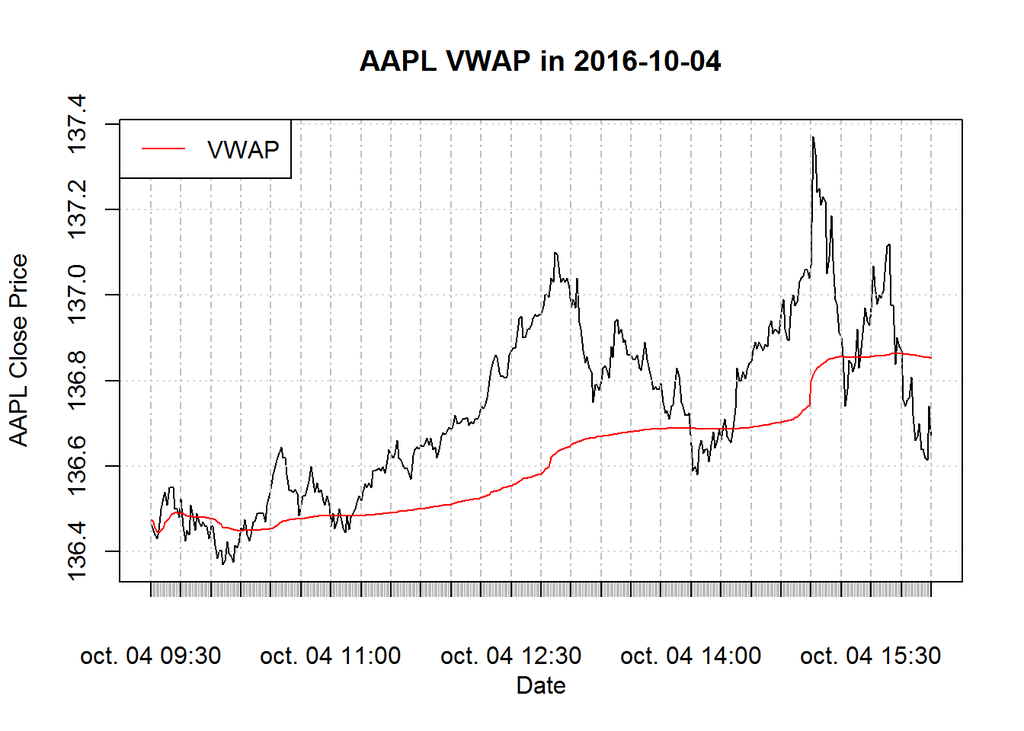

## Sharp ratio

```
##                               strategyreturn minutereturn
## StdDev Sharpe (Rf=0%, p=95%):     0.05470457   0.01321353
## VaR Sharpe (Rf=0%, p=95%):        0.03562849   0.01082059
## ES Sharpe (Rf=0%, p=95%):         0.01649684   0.01082059
```

# Mean Reversion Test

Trading strategies can be profitable only if securities prices are either mean-reverting or trending. Prices can be both mean reverting and trending at the same time. Detecting whether the stock has mean reversion property is our goal.  
Mean reverting means that the stochastic part should be stationary and shocks have transitory effects. That means that it should be trend stationary then difference stationary. More generally, stock price will tend to move to the average price over time. The test method for testing mean reversion is Augmented Dickey-Fuller (ADF) test.

$H_0 : \gamma = 0 \rightarrow$ there exists unit root $\rightarrow$ the series is difference-stationary, not mean-reverting $H_A : \gamma < 0 \rightarrow$ there doesn’t exist unit root $\rightarrow$ the series is trend-stationary $\rightarrow$ mean-reverting
The statistic is :
$$DF = \frac{\hat{\gamma}}{se(\hat{\gamma})}$$
Since it is t-distributed and it is always negative, we reject the null hypothesis when the statistic is less than critical value at certain significant rate.

Suppose that $\alpha$ is the significant level. Since it is a one-side test, we have:
$$Pr(\frac{\hat{\gamma}}{se(\hat{\gamma})} > -Z_{\alpha}) = 1-\alpha$$
Thus, the confidence interval is :
$$[-se(\hat{\gamma})*Z_{\alpha}, \, +\infty]$$

We take day time data of GOOG from 2015-08-19.

## Price tendence

Here is the price tendence :

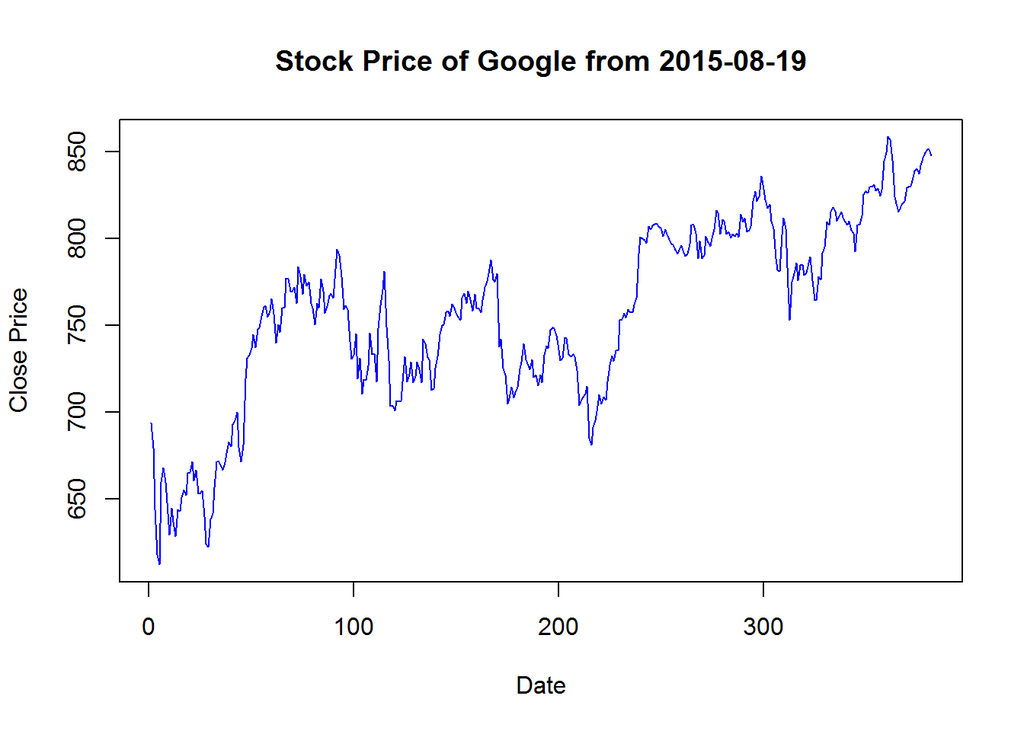

## T-test Value

Firstly, we use just linear regression to calculate t-test value of the statistics. We want to find out $\gamma$.
$$\Delta y_t=\alpha+\beta t + \gamma y_{t-1} + \delta\Delta y_{t-1} +\epsilon_{t}$$

```r
diff.coef <- function(y)
{
#time
t = seq(1:(length(y)-2))

#difference of y_t
y.diff = diff(y)

#difference of y_t
y.t.diff = embed(y.diff, 2)[,1]

#y_t-1
y.t1 = y[2:length(y.diff)]

#difference of y_t-1
y.diff.lag = embed(y.diff, 2)[,2]

formula = lm(y.t.diff ~ t + y.t1 + y.diff.lag)
#summary(formula)

#t-statistic
tsta <- summary(formula)$coefficients[3,3]

#coeff of y_t-1
gamma <- summary(formula)$coefficients[3,1]

return(list(tsta = tsta, gamma = gamma, formula = formula))

}
```

## Results

Now we use a function from the package ‘urca’. In this function, we cannot choose both trend and drift.

```
##
## ###############################################
## # Augmented Dickey-Fuller Test Unit Root Test #
## ###############################################
##
## Test regression trend
##
##
## Call:
## lm(formula = z.diff ~ z.lag.1 + 1 + tt + z.diff.lag)
##
## Residuals:
##     Min      1Q  Median      3Q     Max
## -41.474  -4.673   0.295   5.122  43.537
##
## Coefficients:
##              Estimate Std. Error t value Pr(>|t|)
## (Intercept) 37.238631  11.058696   3.367 0.000837 ***
## z.lag.1     -0.053916   0.016084  -3.352 0.000884 ***
## tt           0.020771   0.007641   2.718 0.006863 **
## z.diff.lag   0.104148   0.051181   2.035 0.042564 *
## ---
## Signif. codes:  0 '***' 0.001 '**' 0.01 '*' 0.05 '.' 0.1 ' ' 1
##
## Residual standard error: 9.928 on 376 degrees of freedom
## Multiple R-squared:  0.03482,    Adjusted R-squared:  0.02712
## F-statistic: 4.522 on 3 and 376 DF,  p-value: 0.00395
##
##
## Value of test-statistic is: -3.3521 3.9652 5.6224
##
## Critical values for test statistics:
##       1pct  5pct 10pct
## tau3 -3.98 -3.42 -3.13
## phi2  6.15  4.71  4.05
## phi3  8.34  6.30  5.36
```

And also this function :

```
##
##  Augmented Dickey-Fuller Test
##
## data:  close
## Dickey-Fuller = -3.3521, Lag order = 1, p-value = 0.06233
## alternative hypothesis: stationary
```

# Half-life of Mean Reversion

Even the process is not mean reverting, in practical trading, we can profit from process that are less certain.Thus, a stock which doesn’t pass the ADF test still have chances to be profitable.
Half-life of mean reversion is to decide how long the price will mean revert. By mathematical deduction, half-life is :
$$H = \frac{\log(2)}{-\gamma}$$

```r
#half-life
H <- log(2)/ (-diff.coef(close)$gamma)
H
```

```
## [1] 12.85606
```

## Cointegration test

Most prices series are not mean reverting or even stationary. However, a linear combination of nonstationary series can be stationary. This kind of series is called cointegrated series. Most common strategies by using cointergration is “pair trading”, which means that we long an asset meanwhile we short another one with a certain amount. But cointegration can also be applied to three or more assets’ combinations.  
Two tests will be conducted : the Cointergrated Augmented Dickey-Fuller (CADF) test and the Johansen test. The first one is just for two assets while the second one can be used to more assets.

### CADF test

The CADF test has the same principles as the ADF test, the only difference is that the object of the CADF test is the residuals of linear combinations of two nonlinear series. We choose one-day data of EWA (iShares MSCI Australia) and EWC (iShares MSCI Canada) from 2006-04-26 to 2012-04-26.

```
## [1] "EWA"
```

```
## [1] "EWC"
```

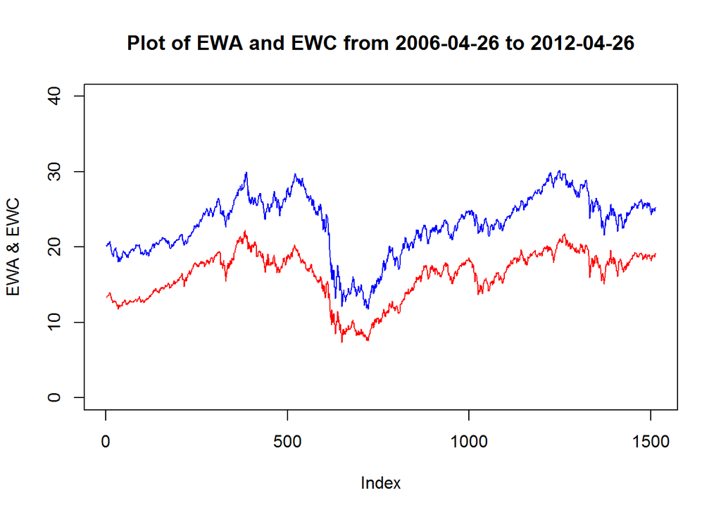

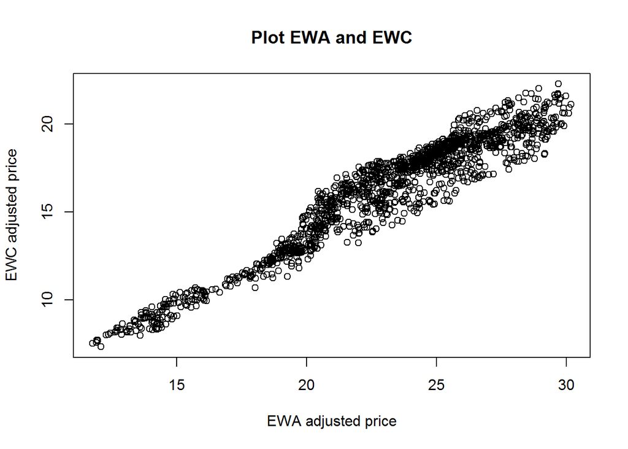

```r
#we suppose that there is no intercept
formula.ewa <- lm(ewa ~ 0 + ewc)
res.ewa <- formula.ewa$residuals

formula.ewc <- lm(ewc ~ 0 + ewa)
res.ewc <- formula.ewc$residuals
```

```r
#Attention: we set lag = 1
adf.test(res.ewa, k = 1)
```

```
##
##  Augmented Dickey-Fuller Test
##
## data:  res.ewa
## Dickey-Fuller = -3.4098, Lag order = 1, p-value = 0.05174
## alternative hypothesis: stationary
```

```r
adf.test(res.ewc, k = 1)
```

```
##
##  Augmented Dickey-Fuller Test
##
## data:  res.ewc
## Dickey-Fuller = -3.4192, Lag order = 1, p-value = 0.05012
## alternative hypothesis: stationary
```

#### Hedge Ratio

Hedge ratio is a value to determine the percentage of hedge. For instance, if we buy 100 lots of EWA, we may sell 70 lots of EWC for hedging.

```
##       ewc
## 0.7061736
```

### Johansen test

The CADF test can just identify cointegration in pair. However, the Johansen test can test three or more series at the same time. This time, parameters are vectors or matrix. We just consider $lag = 1$.
$$\Delta y_t=M + \Gamma y_{t-1} + A\Delta y_{t-1} +\epsilon_{t}$$
Suppose that $r$ is the rank of $\Gamma$. Obviously, $r$ is from zero to $n$. If all series have unit roots, namely, non-stationary, $r$ is at most $n-1$. However, if there is at least one series is stationary, $r$ can be $n$. $n$ tests are conducted to determine the number of cointegrations. The first null hypothesis is that $r$ is zero which means there is no cointegrations. The first non-zero number is the number of cointegrated series. The $n^{th}$ null hyperthesis is that $r \leq n-1$. We add another ETF to this test : IGE (an ETF consisting natural resource stocks). The test function is available in package ‘urca’.

```
##
## ######################
## # Johansen-Procedure #
## ######################
##
## Test type: trace statistic , without linear trend and constant in cointegration
##
## Eigenvalues (lambda):
## [1] 1.154361e-02 8.341198e-03 2.952685e-03 1.734723e-18
##
## Values of teststatistic and critical values of test:
##
##           test 10pct  5pct  1pct
## r <= 2 |  4.47  7.52  9.24 12.97
## r <= 1 | 17.12 17.85 19.96 24.60
## r = 0  | 34.67 32.00 34.91 41.07
##
## Eigenvectors, normalised to first column:
## (These are the cointegration relations)
##
##                 EWA.Adjusted.l1 EWC.Adjusted.l1 IGE.Adjusted.l1   constant
## EWA.Adjusted.l1       1.0000000        1.000000        1.000000  1.0000000
## EWC.Adjusted.l1      -1.1489314        2.713697        3.433515 -0.1102856
## IGE.Adjusted.l1       0.2587311       -2.690139       -1.312495  0.3204871
## constant              1.8868846        8.138352      -55.111138 -3.9337025
##
## Weights W:
## (This is the loading matrix)
##
##                EWA.Adjusted.l1 EWC.Adjusted.l1 IGE.Adjusted.l1
## EWA.Adjusted.d    -0.006623184     0.004504811   -0.0012677203
## EWC.Adjusted.d     0.020558987     0.004747640   -0.0013000800
## IGE.Adjusted.d     0.025454050     0.011231613   -0.0009553288
##                     constant
## EWA.Adjusted.d -1.043646e-18
## EWC.Adjusted.d -1.835563e-18
## IGE.Adjusted.d -3.367817e-18
```

```
## [1] "SPY"
```

```
## [1] "IVV"
```

```
## [1] "VOO"
```

```
##
## ######################
## # Johansen-Procedure #
## ######################
##
## Test type: trace statistic , with linear trend
##
## Eigenvalues (lambda):
## [1] 0.2973598 0.2384406 0.0396155
##
## Values of teststatistic and critical values of test:
##
##            test 10pct  5pct  1pct
## r <= 2 |   8.41  6.50  8.18 11.65
## r <= 1 |  65.06 15.66 17.95 23.52
## r = 0  | 138.47 28.71 31.52 37.22
##
## Eigenvectors, normalised to first column:
## (These are the cointegration relations)
##
##                 SPY.Adjusted.l1 IVV.Adjusted.l1 VOO.Adjusted.l1
## SPY.Adjusted.l1       1.0000000        1.000000       1.0000000
## IVV.Adjusted.l1       0.0651554       -2.231217       0.2263118
## VOO.Adjusted.l1      -1.1605254        1.373077      -1.1611753
##
## Weights W:
## (This is the loading matrix)
##
##                SPY.Adjusted.l1 IVV.Adjusted.l1 VOO.Adjusted.l1
## SPY.Adjusted.d      -1.1490427      -0.8288188      -0.4291356
## IVV.Adjusted.d      -0.7265802      -0.5413024      -0.4376568
## VOO.Adjusted.d      -0.3637033      -0.7558542      -0.3972619
```

As we can see, three statistics are all larger than values at 95% level. Compared to the first test, now we can get a portfolio consisting three cointegrated ETFs. However, unfortunately, if we change the time of historical data, the results change too. Thus, not all cointegrated will endure for long time.

### Bollinger Band mean reversion strategy

This strategy is referenced to Bollinger Band which uses standard deviation to create long and short signals. While in this strategy, we apply not exactly Bollinger Band but spread Z-Score which is centralized by moving average and centralized by moving standard deviation.
$$Z-Score = \frac{price - moving\,\,average}{moving\,\,standard\,\,deviation}$$
How we use Z-Score to determine buy and sell positions?

1. If the strategy is conducted for a pair of assets, using hedge ratio to determine the portfolio spread; if the strategy is conducted for more than two assets, using eigenvector in Johansen test to determine the portfolio spread.
2. Once we get the spread, Z-Score of the spread can be calculated. For determine entry and exit point of each position, we set $entry.value$ and $exit.value$ to control the interval of entry and exit. (*Going long means that we buy low and sell high; going short means that we sell high and buy low.) We decide these two values randomly, $entry.value = 1$ and $exit.value = 0$, which means we conduct long position only when the spread is lower than 1, the vice versa is for short.

In this case, we choose EWA/EWC as a pair of trading.

```
##     Min.  1st Qu.   Median     Mean  3rd Qu.     Max.     NA's
## -28.9000  -2.0910   0.3299  -0.3523   2.0510  22.3700       73
```

As Z-Score shows, we can choose an entry point larger than 5 based on how many trasactions that we want and more importantly the risks and trading costs, here we take 6. And we take exit value randomly.

[output not shown]

Here is the return of this portfolio.

```
## [1] -0.9804414 -0.9779335 -0.9739311 -0.9595149 -0.9790630 -0.9782272
```

## Questions

1. line 509: Hedge ration is not an, how to define buy and sell lots which are interger?
2. For EWA & EWC pair trading, some parameters can be change.
1. Hedge ratio will change as price change.
2. Buy and sell quantities can also be a parameter to be changed.
3. We choose which period?

## References

[1] Chan, E. (2013). Algorithmic Trading. Wiley.  
[2] Anon, (2016). [online] Available at: http://www.jerrydwyer.com/pdf/Clemson/Cointegration.pdf [Accessed 4 Nov. 2016].  
[3] R-forge.r-project.org. (2016). [online] Available at: https://r-forge.r-project.org/scm/viewvc.php/*checkout*/pkg/inst/doc/IntroductionToPairTrading.pdf?revision=6&root=pairtrading&pathrev=6 [Accessed 4 Nov. 2016].  
[4] Anon, (2016). [online] Available at: http://www.jerrydwyer.com/pdf/Clemson/Cointegration.pdf [Accessed 4 Nov. 2016].